# Homework #2 Solutions STAT 506 Spring 2015

1. Researchers in Jordan are interested in plants useable for animal fodder which require little moisture. They tested four plant species in a greenhouse experiment varying the daily watering from 50 to 650 mm in 100 mm increments. Within each species, water amounts were allocated at random. The response is dry biomass. Read in the [data here](http://www.math.montana.edu/~jimrc/classes/stat505/data/plantBiomass.csv)
   1. Plot the data in a manner which allows us to easily compare median biomass for each species as a function of water.

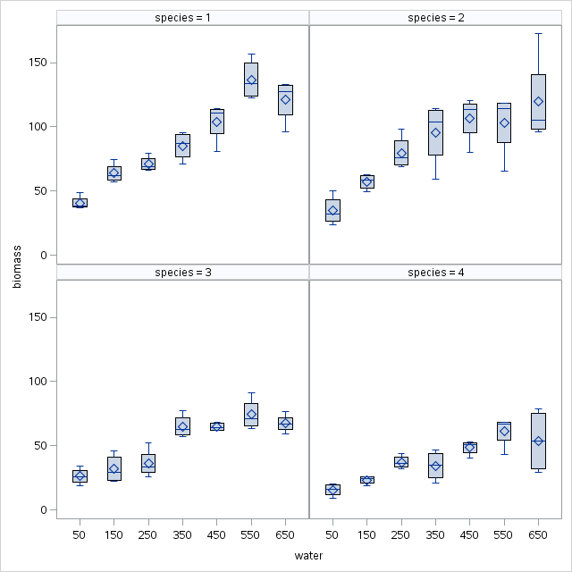

   2. Fit a model with an intercept and the interaction model: $y_i = \beta_0 + \beta_1 x_i + \alpha_{0j[i]} + \alpha_{1j[i]} x_i + \epsilon_i$  
      In this notation, $i$ is the row number, $j[i]$ is the plant species of the plant in row $i$ ($j = 1$ to 4), $\beta$’s are overall effects, and $\alpha$’s are adjustments for each plant species.
      1. Fit this model in SAS and show the estimated coefficients.

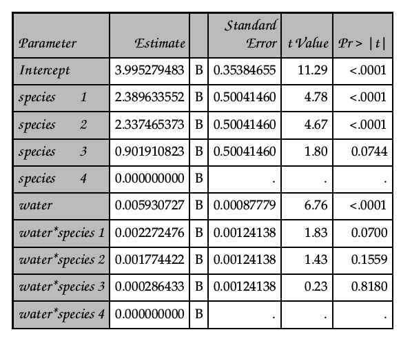

      2. Provide either the Type I or Type III output table, and explain why you think this table is preferred. Is the interaction needed?  
         *I would favor Type I sums of squares because it makes no sense to look at the need for a main effect when the model includes an interaction of that main effect and some other predictor. However, this is balanced data, so the columns of X are orthogonal, and ordering doesn’t matter.*

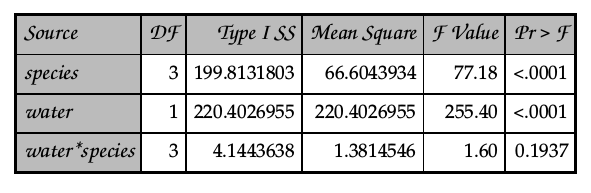

      3. What combination of Greek letters is estimated by each coefficient shown?

      Plot the four lines.

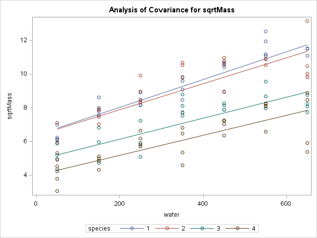

      Slopes appear to be quite similar, which makes sense since the interaction term  
      has a large p-value.